# Clima do Paraná: Londrina

NASA POWER, dados horários agregados por dia

# 1. Estatística descritiva

| variavel | media | mediana | moda | minimo | maximo | amplitude | variancia | desvio_pad | cv_pct | q1 | q3 | iqr |
| --- | --- | --- | --- | --- | --- | --- | --- | --- | --- | --- | --- | --- |
| Temperatura média (°C) | 21,87 | 22,55 | 23,0 | 6,29 | 31,38 | 25,09 | 15,85 | 3,98 | 18,20 | 19,29 | 24,83 | 5,54 |
| Temperatura máxima (°C) | 28,46 | 28,70 | 28,4 | 11,94 | 39,74 | 27,80 | 18,13 | 4,26 | 14,96 | 25,97 | 31,47 | 5,50 |
| Temperatura mínima (°C) | 16,19 | 16,72 | 17,3 | -0,13 | 25,18 | 25,31 | 17,82 | 4,22 | 26,08 | 13,44 | 19,62 | 6,18 |
| Ponto de orvalho (°C) | 15,41 | 15,95 | 20,1 | -2,38 | 23,07 | 25,45 | 18,27 | 4,27 | 27,74 | 12,57 | 18,81 | 6,24 |
| Chuva (mm/dia) | 3,11 | 0,23 | 0,0 | 0,00 | 60,77 | 60,77 | 45,31 | 6,73 | 216,13 | 0,00 | 3,06 | 3,06 |
| Umidade (%) | 70,64 | 70,98 | 66,3 | 34,61 | 95,17 | 60,55 | 129,38 | 11,37 | 16,10 | 63,09 | 78,92 | 15,83 |
| Radiação (MJ/m²/dia) | 18,23 | 18,01 | 16,3 | 1,09 | 32,59 | 31,50 | 41,63 | 6,45 | 35,39 | 14,43 | 22,70 | 8,27 |
| Vento a 2 m (m/s) | 1,90 | 1,81 | 1,8 | 0,59 | 4,47 | 3,87 | 0,37 | 0,61 | 32,13 | 1,46 | 2,23 | 0,77 |
| DPV (kPa) | 0,96 | 0,90 | 0,6 | 0,08 | 2,75 | 2,67 | 0,24 | 0,49 | 50,78 | 0,60 | 1,25 | 0,65 |

# 2. Gráficos

## 2.1 Distribuição da temperatura média diária

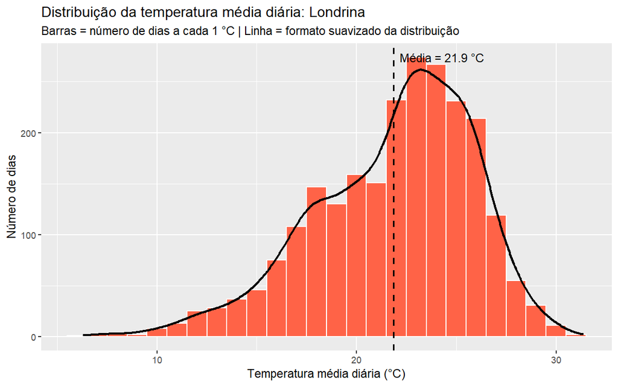

## 2.2 Dias por intensidade de chuva

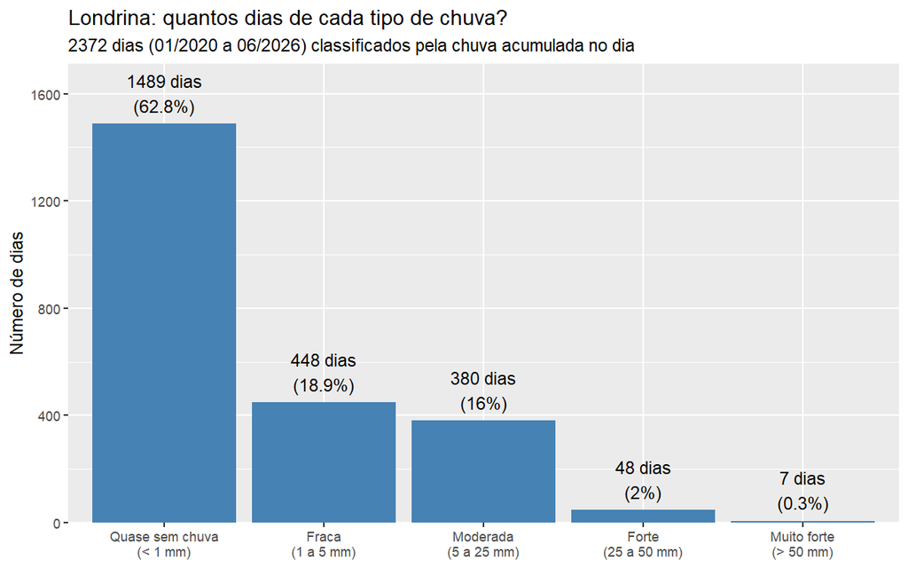

## 2.3 Temperatura média por mês

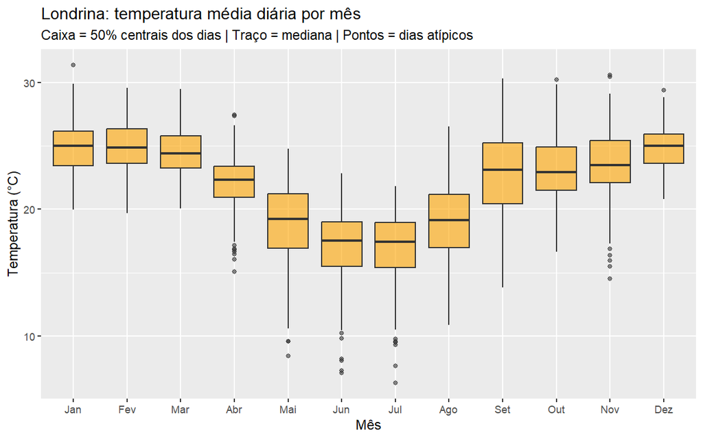

## 2.4 Temperatura ao longo do tempo

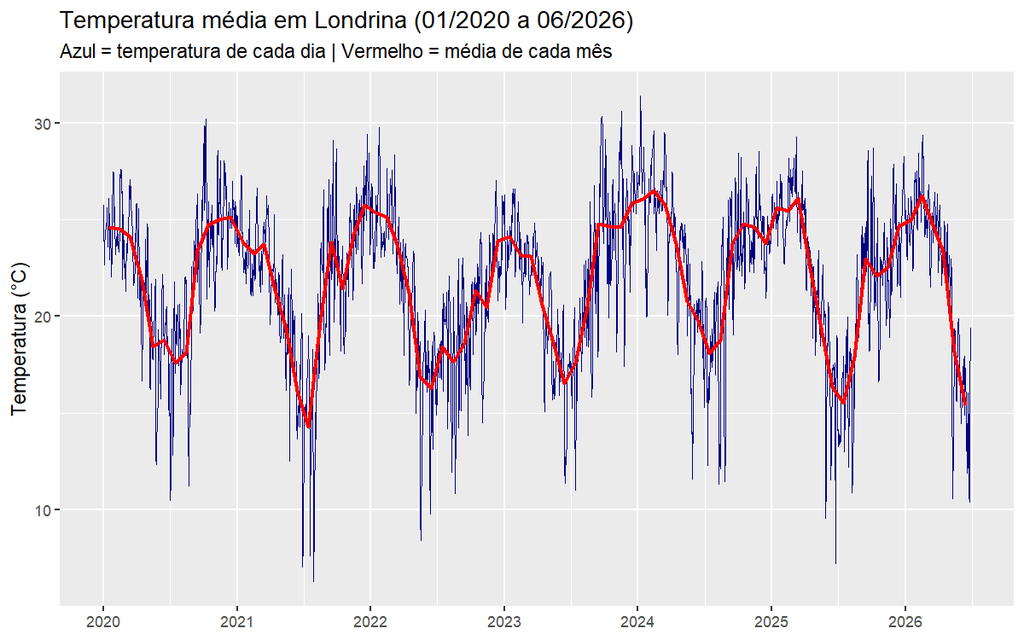

## 2.5 Radiação solar × temperatura

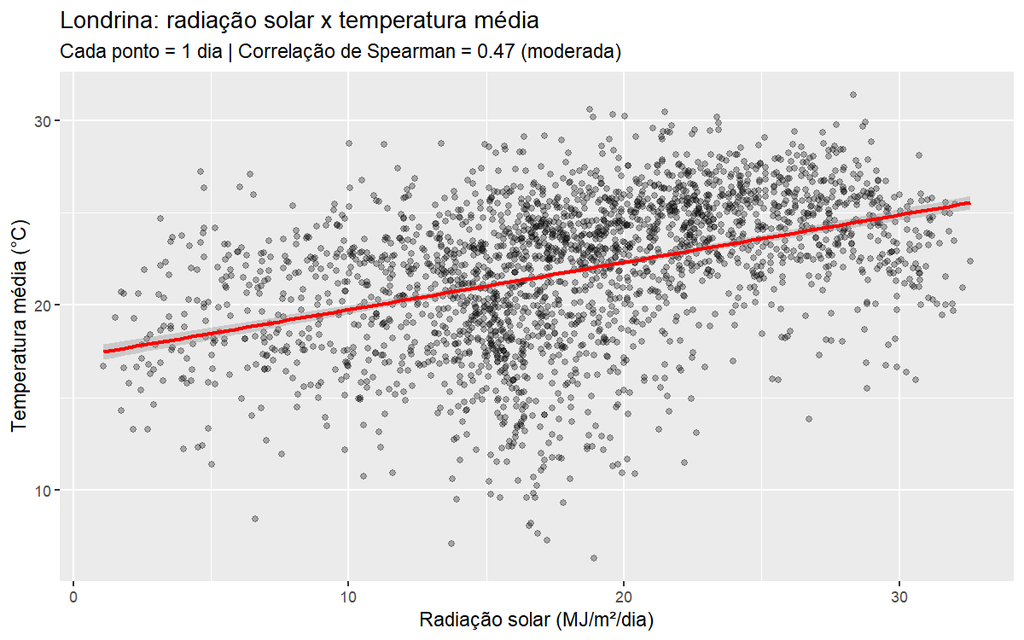

## 2.6 Temperaturas máxima, média e mínima por mês

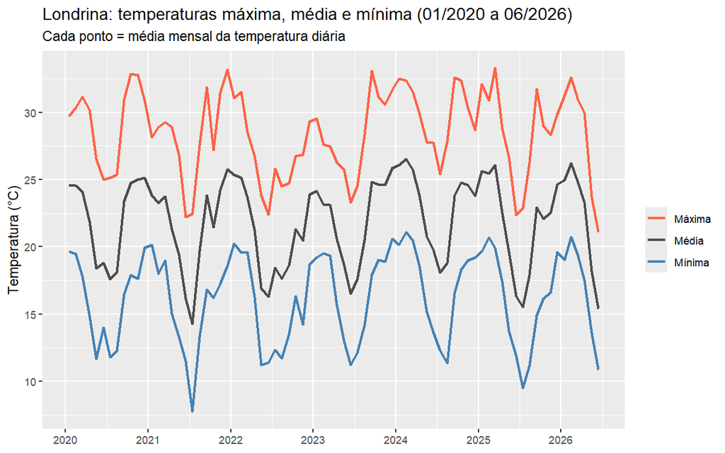

## 2.7 Velocidade do vento por mês

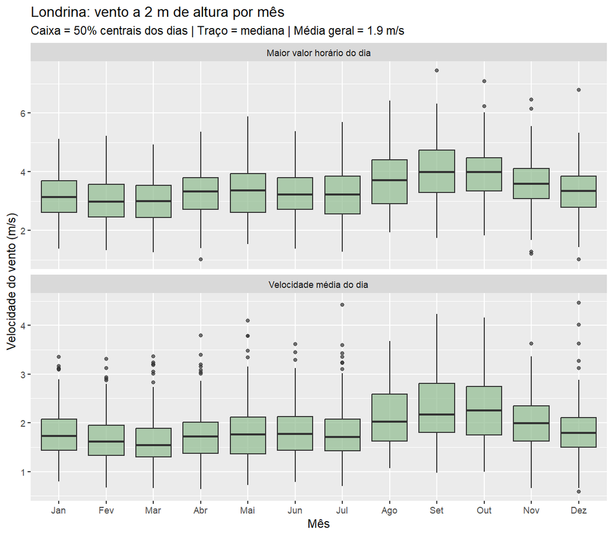

# 3. Teste de normalidade (Shapiro-Wilk)

| Variável | W | p-valor | Decisão |
| --- | --- | --- | --- |
| Temperatura média (°C) | 0.971 | < 0,001 | Não normal (rejeita H0) |
| Temperatura máxima (°C) | 0.989 | < 0,001 | Não normal (rejeita H0) |
| Temperatura mínima (°C) | 0.966 | < 0,001 | Não normal (rejeita H0) |
| Ponto de orvalho (°C) | 0.962 | < 0,001 | Não normal (rejeita H0) |
| Chuva (mm/dia) | 0.519 | < 0,001 | Não normal (rejeita H0) |
| Umidade (%) | 0.992 | < 0,001 | Não normal (rejeita H0) |
| Radiação (MJ/m²/dia) | 0.990 | < 0,001 | Não normal (rejeita H0) |
| Vento a 2 m (m/s) | 0.961 | < 0,001 | Não normal (rejeita H0) |
| DPV (kPa) | 0.961 | < 0,001 | Não normal (rejeita H0) |

## Q-Q plots

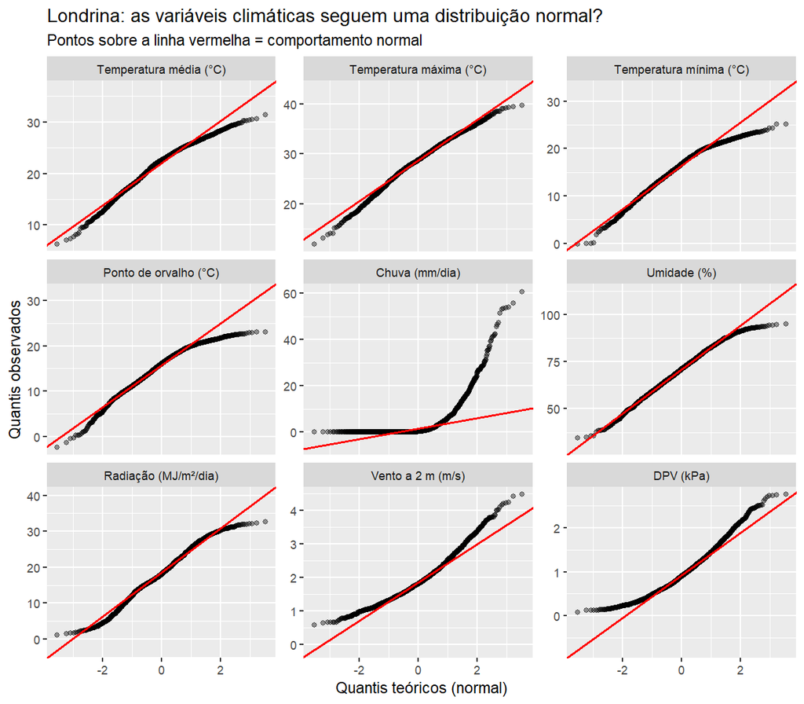

# 4. Teste de correlação (Spearman)

H0: não há correlação (rho = 0). H1: há correlação (rho ≠ 0). Escala de |rho|: 0,00-0,19 muito fraca; 0,20-0,39 fraca; 0,40-0,69 moderada; 0,70-0,89 forte; 0,90-1,00 muito forte.

Dos 36 pares, **35 são significativos** (p < 0,05).

| Par | rho | p-valor | Força | Sentido | Decisão |
| --- | --- | --- | --- | --- | --- |
| Umidade × DPV | -0.90 | < 0,001 | Muito forte | Negativa | Correlação significativa |
| Temp. média × Temp. máx. | 0.89 | < 0,001 | Forte | Positiva | Correlação significativa |
| Temp. média × Temp. mín. | 0.89 | < 0,001 | Forte | Positiva | Correlação significativa |
| Temp. mín. × P. orvalho | 0.89 | < 0,001 | Forte | Positiva | Correlação significativa |
| Temp. máx. × DPV | 0.87 | < 0,001 | Forte | Positiva | Correlação significativa |
| Temp. média × P. orvalho | 0.68 | < 0,001 | Moderada | Positiva | Correlação significativa |
| P. orvalho × Chuva | 0.65 | < 0,001 | Moderada | Positiva | Correlação significativa |
| Temp. média × DPV | 0.62 | < 0,001 | Moderada | Positiva | Correlação significativa |
| Temp. máx. × Temp. mín. | 0.62 | < 0,001 | Moderada | Positiva | Correlação significativa |
| Chuva × Umidade | 0.59 | < 0,001 | Moderada | Positiva | Correlação significativa |
| Radiação × DPV | 0.59 | < 0,001 | Moderada | Positiva | Correlação significativa |
| Temp. máx. × Umidade | -0.58 | < 0,001 | Moderada | Negativa | Correlação significativa |
| Temp. máx. × Radiação | 0.57 | < 0,001 | Moderada | Positiva | Correlação significativa |
| Temp. mín. × Chuva | 0.51 | < 0,001 | Moderada | Positiva | Correlação significativa |
| P. orvalho × Umidade | 0.49 | < 0,001 | Moderada | Positiva | Correlação significativa |
| Temp. média × Radiação | 0.47 | < 0,001 | Moderada | Positiva | Correlação significativa |
| Umidade × Radiação | -0.47 | < 0,001 | Moderada | Negativa | Correlação significativa |
| Chuva × DPV | -0.39 | < 0,001 | Fraca | Negativa | Correlação significativa |
| Temp. máx. × P. orvalho | 0.34 | < 0,001 | Fraca | Positiva | Correlação significativa |
| Chuva × Radiação | -0.32 | < 0,001 | Fraca | Negativa | Correlação significativa |
| Temp. média × Umidade | -0.25 | < 0,001 | Fraca | Negativa | Correlação significativa |
| Temp. mín. × DPV | 0.25 | < 0,001 | Fraca | Positiva | Correlação significativa |
| Temp. média × Chuva | 0.24 | < 0,001 | Fraca | Positiva | Correlação significativa |
| Temp. mín. × Radiação | 0.20 | < 0,001 | Fraca | Positiva | Correlação significativa |
| Temp. mín. × Vento | -0.18 | < 0,001 | Muito fraca | Negativa | Correlação significativa |
| P. orvalho × Vento | -0.18 | < 0,001 | Muito fraca | Negativa | Correlação significativa |
| Temp. média × Vento | -0.16 | < 0,001 | Muito fraca | Negativa | Correlação significativa |
| Temp. mín. × Umidade | 0.13 | < 0,001 | Muito fraca | Positiva | Correlação significativa |
| P. orvalho × DPV | -0.11 | < 0,001 | Muito fraca | Negativa | Correlação significativa |
| P. orvalho × Radiação | 0.08 | < 0,001 | Muito fraca | Positiva | Correlação significativa |
| Chuva × Vento | -0.08 | < 0,001 | Muito fraca | Negativa | Correlação significativa |
| Temp. máx. × Chuva | -0.07 | < 0,001 | Muito fraca | Negativa | Correlação significativa |
| Temp. máx. × Vento | -0.07 | 0,001 | Muito fraca | Negativa | Correlação significativa |
| Umidade × Vento | -0.05 | 0,010 | Muito fraca | Negativa | Correlação significativa |
| Radiação × Vento | -0.04 | 0,031 | Muito fraca | Negativa | Correlação significativa |
| Vento × DPV | -0.02 | 0,262 | Muito fraca | Negativa | Sem evidência de correlação |

## Mapa de calor

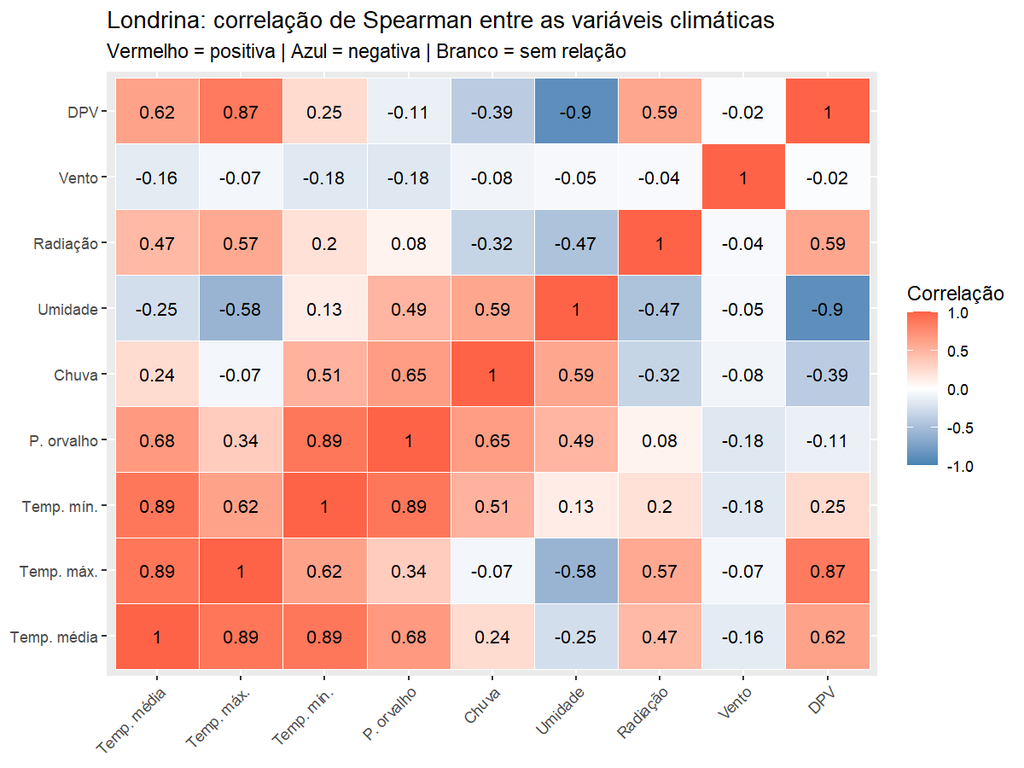

## Pearson (apenas para comparação: radiação × temperatura)

r = 0.42 (IC 95%: 0.38 a 0.45), p-valor < 0,001.

# Observações

- O NASA POWER é derivado de satélites e modelos (grade de ~50 km), não de estações; a chuva é a variável menos confiável.
- Os dados são **horários** (hora solar local) e foram agregados por dia: média para temperatura, umidade, vento, ponto de orvalho e DPV; soma dos valores horários para chuva (mm) e radiação (MJ/m²); máximo e mínimo dos valores horários para `temp_max`, `temp_min` e `vento_max`. Como cada valor horário já é uma média de uma hora, os extremos diários são um pouco mais suaves que os de uma estação.
- O DPV e o ponto de orvalho são calculados **hora a hora** (fórmula de Magnus) e só depois viram média diária, o que evita o viés de calcular a partir de médias diárias. Ainda assim, suas correlações com temperatura e umidade são em parte matemáticas.
- O período vai de 2020 até a data mais recente disponível (a NASA tem alguns dias de atraso). O último mês costuma estar incompleto, e a sazonalidade deixa os p-valores otimistas. Correlação não implica causa.